# A Shallow Dive into Time Series: Analysis of Local Restaurant Data Using R

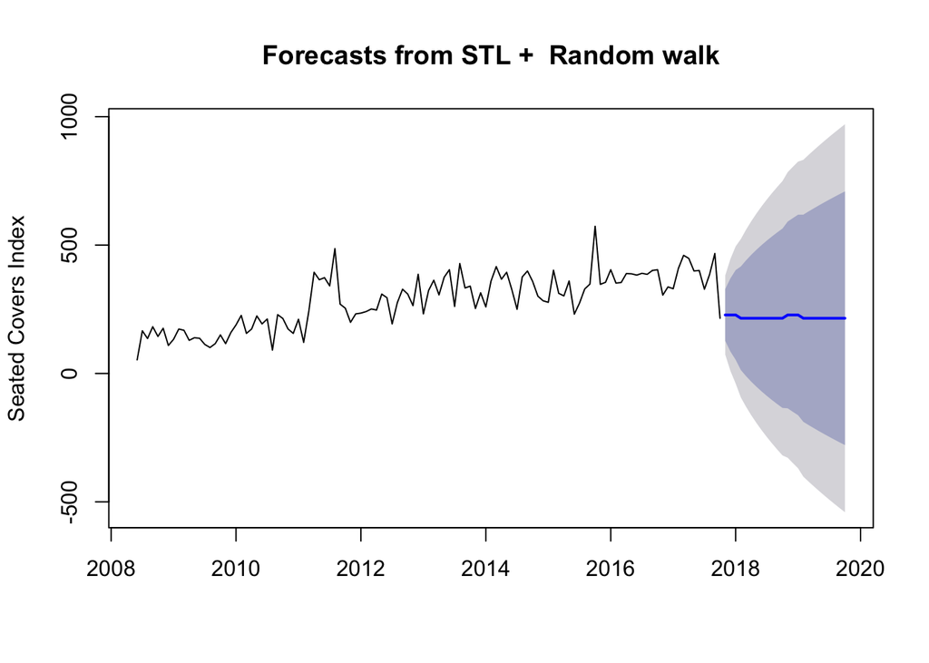

```r
sc_ts_forecast <- forecast(sc_ts_fit, method = "naive")
# Typically useful for stock market time series
# (where the last periods actual numbers are used in current
# forecast) Used for highly seasonal data.

plot(sc_ts_forecast, ylab = "Seated Covers Index")
```

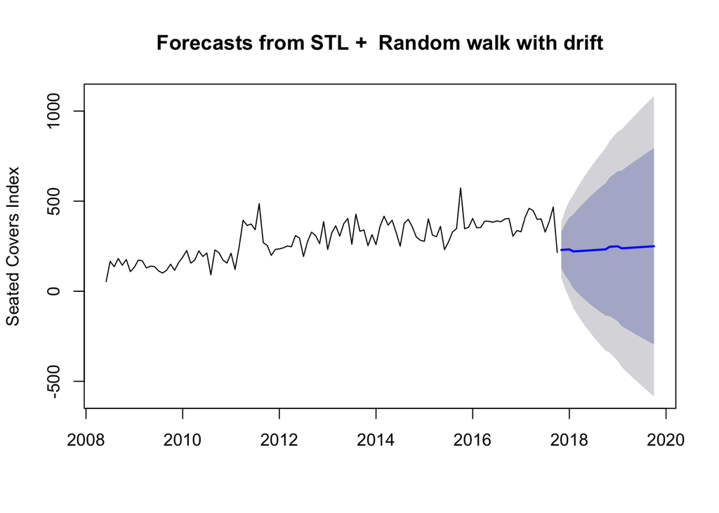

```r
sc_ts_forecast <- forecast(sc_ts_fit, method = "rwdrift")
# Similar to extrapolating a line between the first and last observations
# (a variation of the naive method that allows for forecasts to
# increase and decrease over time) The amount of change or "drift" over time is
# set to be the historical average.

plot(sc_ts_forecast, ylab = "Seated Covers Index")
```

*** These are the forecasts I have decided to settle on and I believe they are a good place to begin to think about what the restaurant can expect over time.

I now go a bit further and take some extra ratings data for a sixty day span from the restaurant and simply visualize it in barchart form. This may lead to some other insights.

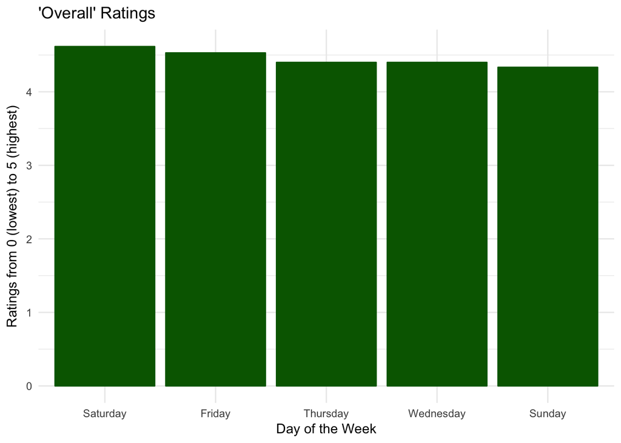

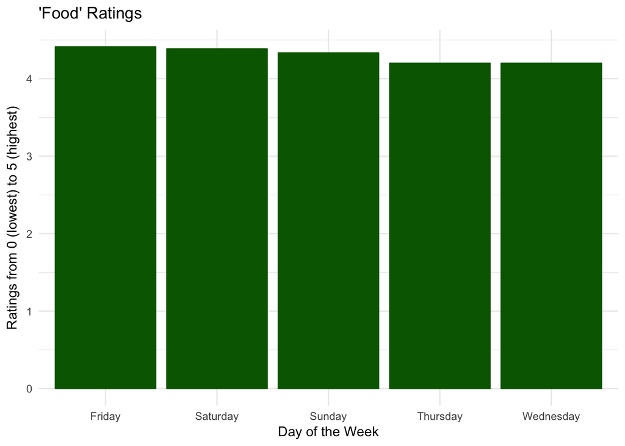

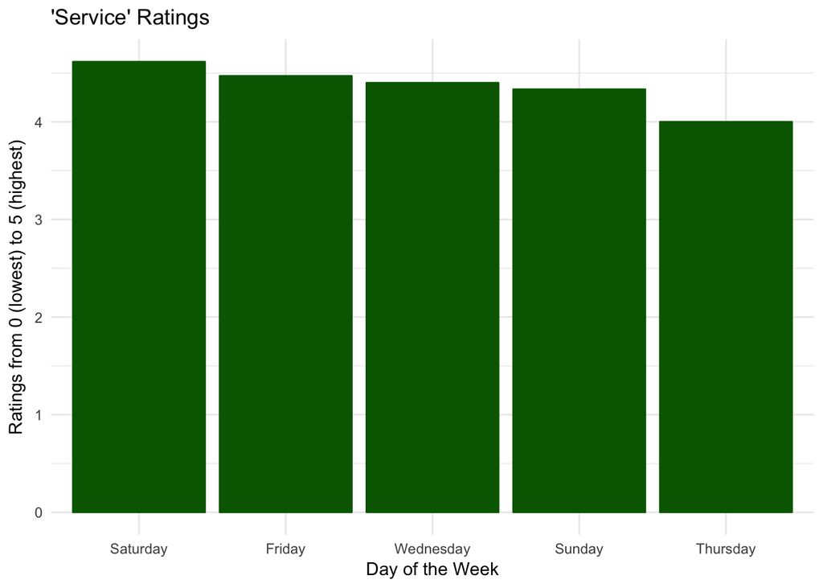

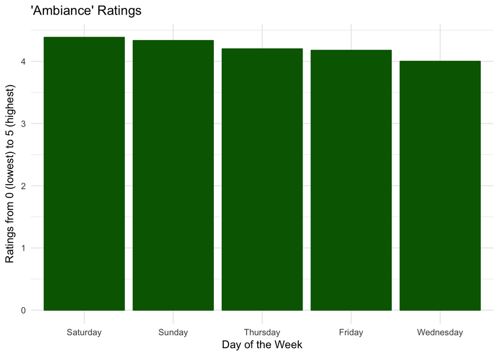

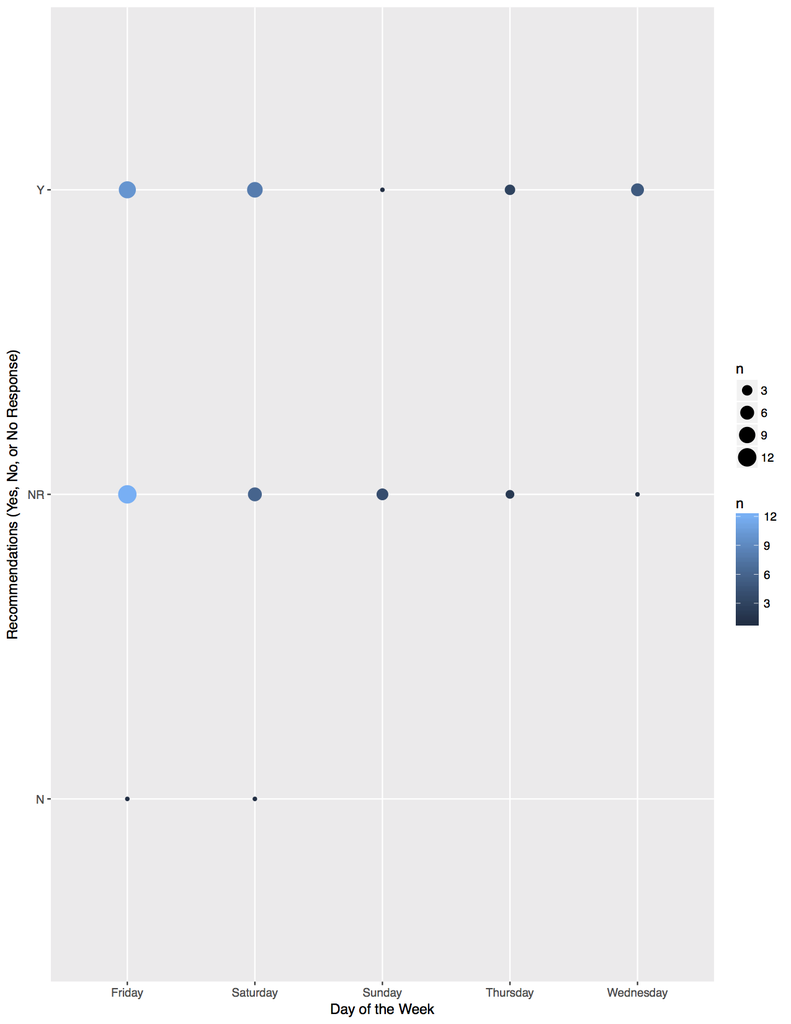

#### Results:

Lastly, we see in the final plot for recommendations a confirmation of the findings from the earlier barcharts. Sunday is the day that receives the least number of “yes” recommendations while Friday receives the most. The day most likely to receive a “No Response” is Friday. There are only a small number of “no” recommendations for Friday and Saturday whereas the other days of the week do not have data for “no” recommendations.

#### Discussion:

These time series forecast plots are useful visualizations that provide a deeper look into business projections otherwise gone unseen and provide information that a simple averaging or listing of data cannot necessarily show without extra manipulation. It is up to the R user to determine what is of importance and why. Your analysis depends on the data you have, and what you are interested in knowing.

Though this all might seem a little complex, there are a few general steps to follow when attempting a time series analysis:

- **Step 1**: Read in the data, make it a time series object, and do some exploratory analysis with plot(), abline(), boxplot(), and summary().
- **Step 2**: Work on stationarization of the data, this process can be a little time consuming and there is not quite one fix-all way to do this, so experiment with adding MA values if needed, differencing the mean, etc.
- **Step 3**: Choose which type of model fitting works best for your data. This is open ended and really depends on the data set (and how much time you have) but ultimately it is important to play around and look at examples to get a feel for what steps to take and what functions to use.
- **Step 4**: Make your forecast! Use a combination of techniques if necessary and see what the future holds. If what you get seems wrong, revise until you’re able to make a few meaningful inferences.

#### Conclusions:

Time series forecasting is an interesting way to delve into the analysis of univariate data, and often we don’t have much more to go off of except the passing of time. It is good to begin to understand how to use the many different methods for such investigation into a dataset, and hopefully this overview has piqued the reader’s interest in further study.

**For the reader:** Time series analysis is a complicated subject when you are just beginning so keep in mind that the more familiar you become with the underlying concepts of time series forecasting the better your intuition will be for making accurate predictions. This was a quick survey of some of the things you can do in R to begin an analysis of a time dependant sequence of data, and by no means did I truly scratch the surface.

#### References:

- https://align-alytics.com/seasonal-decomposition-of-time-series-by-loessan-experiment/
- https://www.jstor.org/stable/2669408?seq=1#page_scan_tab_contents Introduction portion of: Time Series and Forecasting: Brief History and Future Research Ruey S. Tsay Journal of the American Statistical Association Vol. 95, No. 450 (Jun., 2000), pp. 638
- https://onlinecourses.science.psu.edu/stat510/
- https://people.duke.edu/~rnau/411arim.htm
- http://people.duke.edu/~rnau/411fcst.htm
- https://www.stat.berkeley.edu/~brill/Papers/encysbs.pdf
- http://www.statistics.su.se/english/research/time-series-analysis/a-brief-history-of-time-series-analysis-1.259451
- https://www.wessa.net/download/stl.pdf